# Lab 02 - Constructing Groups

30 August, 2022

# Data

The following report identifies specific tax parcels in Downtown Syracuse, New York (USA).

View the dataset documentation here: [Syracuse, NY Tax Parcel Data](https://watts-college.github.io/cpp-526-fall-2022/labs/syr_parcels.html).

## Required Packages

The following packages are required for this report and loaded with `library()`.

```r
library(sp)
library(rgdal)
library(geojsonio)                            # Load required libraries
```

## Import Spatial Polygons

We read in spatial polygons (`"sp"`) with function `geojson_read()` to map tax parcel shapes in Syracuse’s Downtown area.

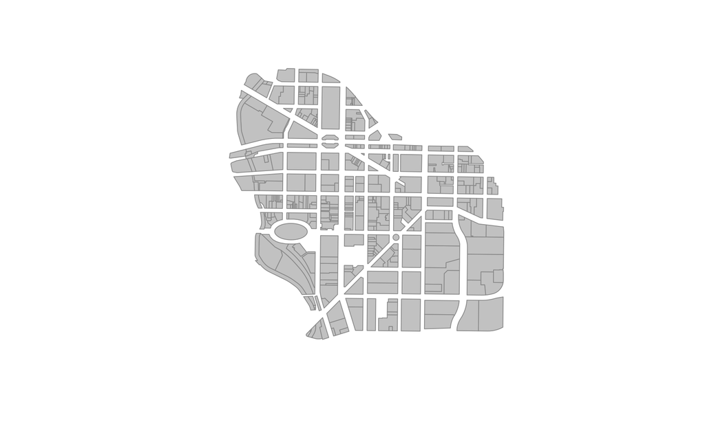

```r
url <- paste0("https://raw.githubusercontent.com/DS4PS/Data",
              "-Science-Class/master/DATA/downtown-syr.geojson")

downtown <- geojson_read(url, what = "sp")    # Load parcel data

plot(downtown,
     border = "gray60",
     col = "gray80")                          # Visualize parcels
```

# Example Solutions

The following examples demonstrate how to use conditions to identify specific parcels.

### Example: Tax Parcel Acres

Parcels with more than one acre are determined with variable `acres` and condition `> 1`.

```r
result <- downtown$acres > 1                  # Each value in 'acres' is tested
```

All `TRUE` and `FALSE` values, for each parcel, are converted into colors.

```r
group.colors <- ifelse(test = result,         # 'test =' accepts TRUE or FALSE values
                       yes = "firebrick",     # 'yes =' converts values that are TRUE
                       no = "gray80")         # 'no =' converts values that are FALSE
```

All tax parcels in `downtown` are mapped with `plot()`. Each parcel has one of two colors per the above code.

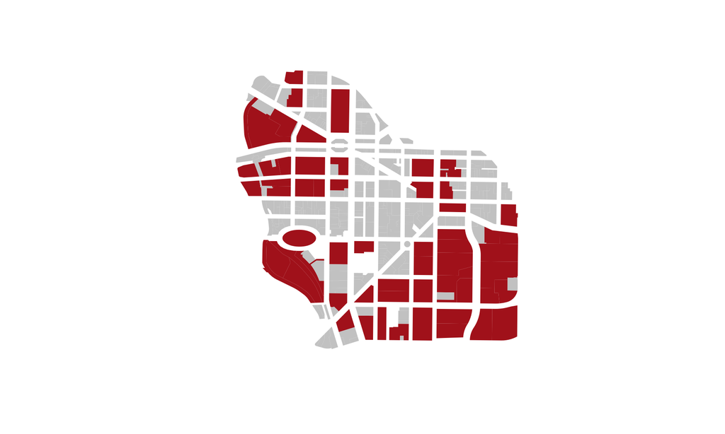

```r
plot(downtown,                                # Plots object 'downtown'
     border = NA,
     col = group.colors)                      # Red when TRUE; gray when FALSE
```

### Example: Parcels with Single Families

Use variable `landuse` to determine how a tax parcel is used. Determine all possible values with `unique()`.

```r
unique(downtown$landuse)                      # All unique values in 'landuse'
```

```
##  [1] "Parking"            "Commercial"         "Parks"
##  [4] "Community Services" "Vacant Land"        "Utilities"
##  [7] "Apartment"          "Recreation"         "Schools"
## [10] "Religious"          "Industrial"         "Single Family"
```

One of the values in `landuse` is “Single Family”. Therefore, the test is whether or not `landuse` is exactly equal to “Single Family”.

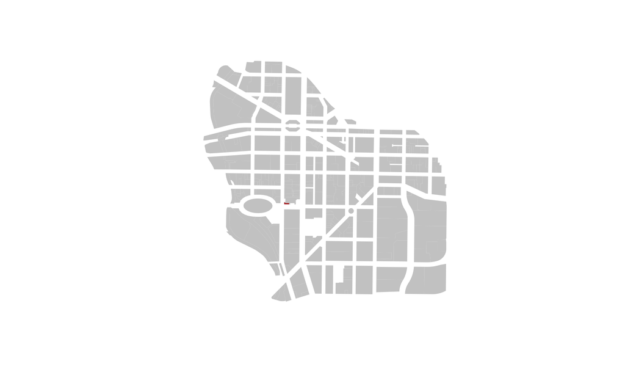

```r
result <- downtown$landuse == "Single Family" # Test if 'landuse' is "Single Family"

group.colors <- ifelse(test = result,         # Provide TRUE or FALSE test results
                       yes = "firebrick",     # If TRUE, make "firebrick"
                       no = "gray80")         # If FALSE, make "gray80"

plot(downtown,
     border = NA,
     col = group.colors)                      # Plot with respective colors
```

# Questions & Solutions

The following questions ask you to map your results, write your answer, or both. The first question has been completed for you.

## Question 1: Vacant Lots

**Question:** *Where are the majority of vacant lots located in downtown Syracuse? Map your results.*

**Note:** *This solution has been provided for you.*

```r
unique(downtown$landuse)                      # Print unique values in 'landuse'
```

```
##  [1] "Parking"            "Commercial"         "Parks"
##  [4] "Community Services" "Vacant Land"        "Utilities"
##  [7] "Apartment"          "Recreation"         "Schools"
## [10] "Religious"          "Industrial"         "Single Family"
```

Now, we create our test statement, `== "Vacant Land"`, and store the results in `result`.

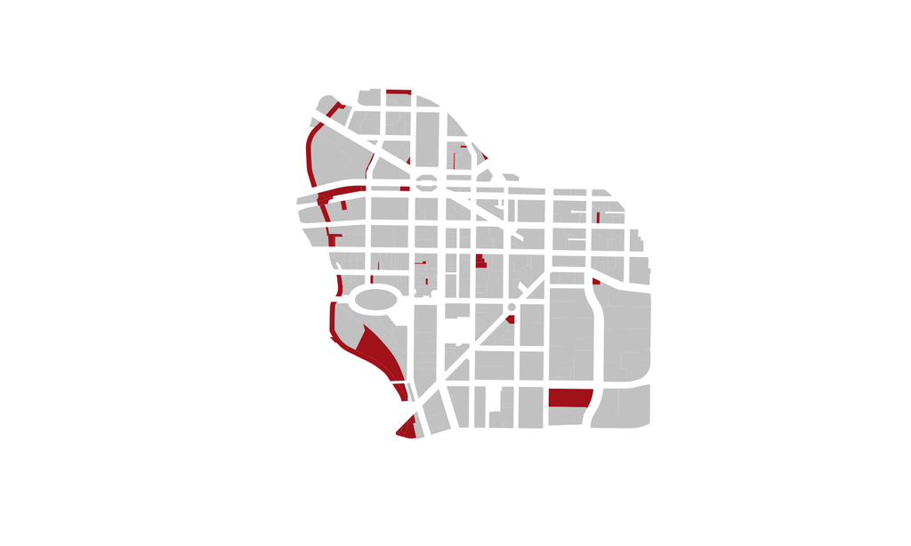

```r
result <- downtown$landuse == "Vacant Land"

group.colors <- ifelse(test = result,
                       yes = "firebrick",
                       no = "gray80")

plot(downtown,
     border = NA,
     col = group.colors)
```

## Question 2: Parking Lots

**Question:** *How many parking lots are in downtown Syracuse? Map your results.*

```r
# Use function: 'sum()'
# Use variable: 'landuse'

# Assign test (logical) output to object 'result' by replacing 'FALSE'

result <- FALSE

group.colors <- ifelse(test = result,
                       yes = "firebrick",
                       no = "gray80")

plot(downtown,
     border = NA,
     col = group.colors)
```

[output not shown]

## Question 3: New Construction

**Question:** *Where is new construction located in the city? Map your results.*

**Note:** You may use `>=` (greater than or equal) or `>` (greater than) 1980.

```r
# Use variable: 'yearbuilt'
# Find the number of buildings constructed either after or during and after than 1980

# Assign test (logical) output to object 'result' by replacing 'FALSE'

result <- FALSE

group.colors <- ifelse(test = result,
                       yes = "firebrick",
                       no = "gray80")

plot(downtown,
     border = NA,
     col = group.colors)
```

[output not shown]

**Question:** *What proportion of commercial properties are built since 1980?*

```r
# Use variable: 'landuse'
# Use variable: 'yearbuilt'
# Count only commercial properties with buildings constructed during or later than 1980
```

## Question 4: Parcels Valued Over $10M

**Question:** *How many parcels have assessed values over $10 million? Map your results.*

```r
# Use function: 'sum()'
# Use variable: 'assessedval'

# Assign test (logical) output to object 'result' by replacing 'FALSE'

result <- FALSE

group.colors <- ifelse(test = result,
                       yes = "firebrick",
                       no = "gray80")

plot(downtown,
     border = NA,
     col = group.colors)
```

[output not shown]

## Question 5: Total Tax Delinquent Parcels

**Question:** *How many properties are delinquent on taxes? Map your results.*

```r
# Use function: 'sum()'
# Use variable: 'amtdelinqt'

# Assign test (logical) output to object 'result' by replacing 'FALSE'

result <- FALSE

group.colors <- ifelse(test = result,
                       yes = "firebrick",
                       no = "gray80")

plot(downtown,
     border = NA,
     col = group.colors)
```

[output not shown]

## Question 6: Tax Delinquent Parcels

**Question:** *What proportion of parcels have delinquent tax payments owed?*

```r
# Use function: 'mean()'
# Use variable: 'amtdelinqt'
```

## Question 7: Tax Delinquent Commercial Properties

**Question I:** *What proportion of commercial properties are delinquent on taxes?*

**Question II:** *What proportion of delinquent tax bills are owed by commercial parcels?*

```r
# Use function: 'mean()'
# Use variable: 'amtdelinqt'
# Use variable: 'landuse'

# The first answer is tax-delinquent commercial properties over all commercial properties
# The second answer is the tax dollars owed by commercial properties (a subset) over all tax dollars owed
```

## Question 8: Tax Delinquent Parcels by Land Use

**Question:** *How many of each land use type are delinquent on taxes? Print a table of your results.*

```r
# Use function: 'table()'
# Use variable: 'amtdelinqt'
# Use variable: 'landuse'
```

————

#### **DELETE THIS LINE & ALL LINES BELOW IF NOT ATTEPTING CHALLENGES**

————

## Challenge I: Parcels Values Over $1M

**Instructions:** *Map all of the land valued at over $1 million per acre.*

```r
# Replace 'FALSE' with your conditional statement

result <- FALSE

group.colors <- ifelse(test = result,
                       yes = "firebrick",
                       no = "gray80")

plot(downtown,
     border = NA,
     col = group.colors)
```

[output not shown]

## Challenge II: Parcels Valued Less Than $500K

**Instructions:** *Map all of the land valued at less than $500,000 per acre.*

```r
# Replace 'FALSE' with your conditional statement

result <- FALSE

group.colors <- ifelse(test = result,
                       yes = "firebrick",
                       no = "gray80")

plot(downtown,
     border = NA,
     col = group.colors)
```

[output not shown]

## Challenge III: Total Commercial Value

**Instructions:** *What is the total value of all of the commercial parcels in downtown Syracuse?*

```r
# Your code here
```

## Challenge IV: Total Non-Commercial Value

**Question:** *What is the total value of all of the non-commercial parcels in downtown Syracuse?*

```r
# Your code here
```

————

#### **DELETE THIS LINE & ALL LINES BELOW BEFORE SUBMITTING**

————

# Tips & Tricks

Consider the following tips for completing this assignment.

### Creating Logical Values

Recall that logical values are `TRUE` and `FALSE`. To produce logical values, we test vaues against a condition, e.g. “greater than”.

```r
x <- c(10, 20, 30, 40, 50)    # Creating a vector of values

x > 25                        # Testing each value as greater than 25
```

```
## [1] FALSE FALSE  TRUE  TRUE  TRUE
```

### Logical Values as Numeric Values

Recall that logical values are `TRUE` and `FALSE`, representing `1` and `0`, respectively.

```r
as.numeric(TRUE)              # Changing class to "numeric"
```

```
## [1] 1
```

```r
as.numeric(FALSE)             # Changing class to "numeric"
```

```
## [1] 0
```

### Logical Values & Arithmetic

Because `TRUE` and `FALSE` are actually numeric, we can use `sum()` for total `TRUE` values, e.g.

```r
y <- c(TRUE, TRUE,
       FALSE, TRUE,
       FALSE, TRUE)           # Creating a vector of TRUE and FALSE

sum(y)                        # Finding total TRUE values
```

```
## [1] 4
```

```r
mean(y)                       # Finding proportion of TRUE values
```

```
## [1] 0.6666667
```

### Logicals for Subsetting

A subset is a smaller collection of observations (rows) from a larger dataset. Create a subset by placing a logical vector in lieu of row positions.

```r
index <- downtown$landuse == "Industrial"   # Test if 'landuse' equals "Industrial"

z <- downtown[index, ]                      # Extract only "Industrial" parcels
```

# How to Submit

Use the following instructions to submit your assignment, which may vary depending on your course’s platform.

### Knitting to HTML

When you have completed your assignment, click the “Knit” button to render your `.RMD` file into a `.HTML` report.

### Special Instructions

Perform the following depending on your course’s platform:

- **Canvas:** Upload both your `.RMD` and `.HTML` files to the appropriate link
- **Blackboard or iCollege:** Compress your `.RMD` and `.HTML` files in a `.ZIP` file and upload to the appropriate link

`.HTML` files are preferred but not allowed by all platforms.

### Before You Submit

Remember to ensure the following before submitting your assignment.

1. Name your files using this format: **Lab-##-LastName.rmd** and **Lab-##-LastName.html**
2. Show both the solution for your code and write out your answers in the body text
3. Do not show excessive output; truncate your output, e.g. with function `head()`
4. Follow appropriate styling conventions, e.g. spaces after commas, etc.
5. Above all, ensure that your conventions are consistent

See [Google’s R Style Guide](https://google.github.io/styleguide/Rguide.xml) for examples of common conventions.

### Common Knitting Issues

`.RMD` files are knit into `.HTML` and other formats procedural, or line-by-line.

- An error in code when knitting will halt the process; error messages will tell you the specific line with the error
- Certain functions like `install.packages()` or `setwd()` are bound to cause errors in knitting
- Altering a dataset or variable in one chunk will affect their use in all later chunks
- If an object is “not found”, make sure it was created or loaded with `library()` in a previous chunk

**If All Else Fails:** If you cannot determine and fix the errors in a code chunk that’s preventing you from knitting your document, add `eval = FALSE` inside the brackets of `{r}` at the beginning of a chunk to ensure that R does not attempt to evaluate it, that is: `{r eval = FALSE}`. This will prevent an erroneous chunk of code from halting the knitting process.